# Analysis of tidyr::billboard dataset

Uyiosa Igbinedion

2022-06-11

## Introduction and dataset overview

The data set has 317 rows which are 317 different song titles that made the billboard top 100 in the defined period. There are 79 columns which are :

1. **artist**
   - Artist name
2. **track**
   - Song name
3. **date.enter**
   - Date the song entered the top 100
4. **wk1 – wk76**
   - Rank of the song in each week after it entered

## Data transformations

The following transformations would be done on the data to prepare it for analysis

1. Change from wide to long format
2. Drop `NA` values
3. Create a merged artist and track column
4. Determine the actual weeks the songs were on the chart

First five rows of the billboard dataset

| artist | track | date.entered | wk1 | wk2 | wk3 | wk4 | wk5 | wk6 | wk7 | wk8 | wk9 | wk10 | wk11 | wk12 | wk13 | wk14 | wk15 | wk16 | wk17 | wk18 | wk19 | wk20 | wk21 | wk22 | wk23 | wk24 | wk25 | wk26 | wk27 | … |
| --- | --- | --- | --- | --- | --- | --- | --- | --- | --- | --- | --- | --- | --- | --- | --- | --- | --- | --- | --- | --- | --- | --- | --- | --- | --- | --- | --- | --- | --- | --- |
| 2 Pac | Baby Don’t Cry (Keep… | 2000-02-26 | 87 | 82 | 72 | 77 | 87 | 94 | 99 | NA | NA | NA | NA | NA | NA | NA | NA | NA | NA | NA | NA | NA | NA | NA | NA | NA | NA | NA | NA | … |
| 2Ge+her | The Hardest Part Of … | 2000-09-02 | 91 | 87 | 92 | NA | NA | NA | NA | NA | NA | NA | NA | NA | NA | NA | NA | NA | NA | NA | NA | NA | NA | NA | NA | NA | NA | NA | NA | … |
| 3 Doors Down | Kryptonite | 2000-04-08 | 81 | 70 | 68 | 67 | 66 | 57 | 54 | 53 | 51 | 51 | 51 | 51 | 47 | 44 | 38 | 28 | 22 | 18 | 18 | 14 | 12 | 7 | 6 | 6 | 6 | 5 | 5 | … |
| 3 Doors Down | Loser | 2000-10-21 | 76 | 76 | 72 | 69 | 67 | 65 | 55 | 59 | 62 | 61 | 61 | 59 | 61 | 66 | 72 | 76 | 75 | 67 | 73 | 70 | NA | NA | NA | NA | NA | NA | NA | … |
| 504 Boyz | Wobble Wobble | 2000-04-15 | 57 | 34 | 25 | 17 | 17 | 31 | 36 | 49 | 53 | 57 | 64 | 70 | 75 | 76 | 78 | 85 | 92 | 96 | NA | NA | NA | NA | NA | NA | NA | NA | NA | … |

### Transformation 1 - 3 : Change from wide to long format, drop `NA` values and create a merged artist and track column

```r
#change dataset from wide to long format and drop na values
billboard2 <- billboard %>% gather(wk1:wk76,key='Week',value ='Position') %>% drop_na(Position) %>% mutate(Year=year(date.entered))

#creating a joined artist and track column
billboard2 <- billboard2 %>% unite(artistTrack, artist, track,sep = ' - ',remove = FALSE)
```

### Transformation 4 : Determine the actual weeks the songs were on the chart

To achieve transformation 4, I attempted 3 approaches:

1. Using base::split() and purrr::map()
2. Using for..loop and dplyr::left_join()
3. Using dplyr::group_split

#### Approach 1 : Using base::split() and purrr::map()

```r
#split creation
billboard3Split <- billboard2 %>% split(.$artistTrack)

#function for map use
addActualWeeks <- function(df){
  df %>% mutate(actualWeeks = seq.Date(ymd(date.entered[1]),by='weeks',length.out = nrow(df)))
}

#creating the additional column with actualweeks
billboardmapped <- map(billboard3Split,addActualWeeks)

#unspliting/combining
billboardcombined <- do.call(rbind,billboardmapped)

#removing rownames
has_rownames(billboardcombined) #TRUE
billboardcombined <- remove_rownames(billboardcombined)
```

#### Approach 2 : Using for..loop and dplyr::left_join()

```r
billboard3 <- billboard2 %>% group_by(artistTrack) %>% summarise(noOfWeeksOnChart=n(),dateEntered=unique(date.entered))
dff <- tibble()
for (i in seq(nrow(billboard3))){
  dff<- rbind(dff,tibble('artistTrack'= billboard3$artistTrack[i],'Week'= paste('wk',seq(billboard3$noOfWeeksOnChart[i]),sep=''),'actualWeeks'= seq.Date(from = billboard3$dateEntered[i],length.out = billboard3$noOfWeeksOnChart[i], by = 'weeks')))
}

billboardjoined <- left_join(dff, billboard2, by=c("artistTrack"='artistTrack','Week'='Week'))
```

#### Approach 3 : Using dplyr::group_split()

I couldn’t create an end-to-end solution with this approach as i didn’t know how to **unsplit** afterwards

## Visualisations

### Viz 1

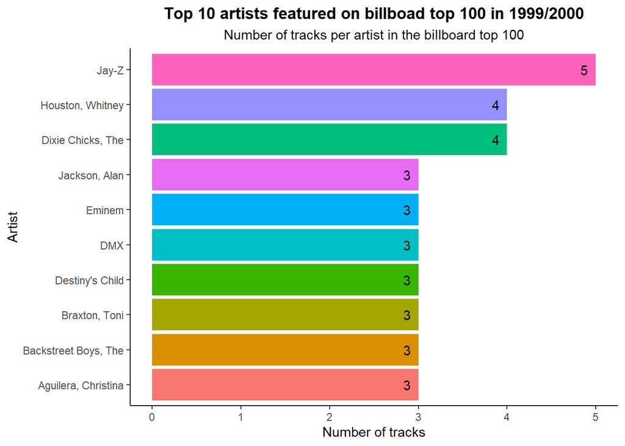

### Viz 2

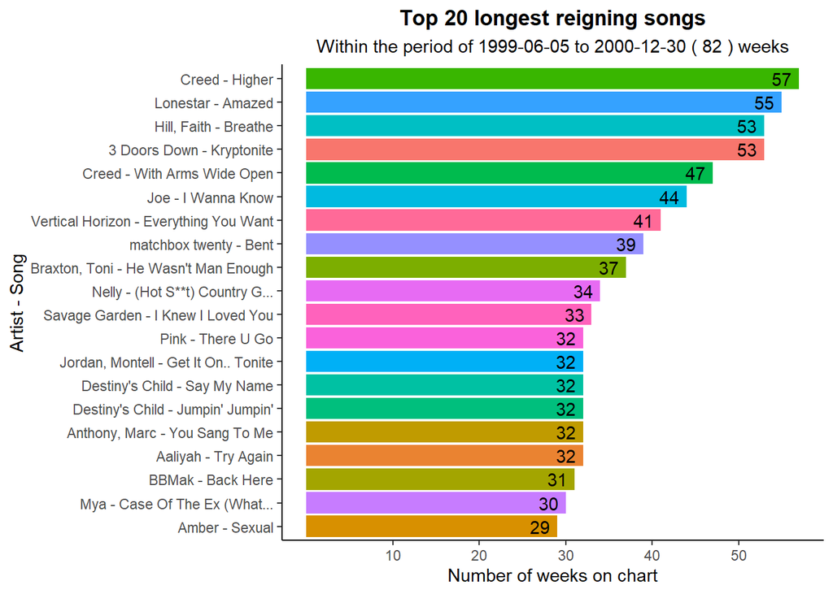

### Viz 3

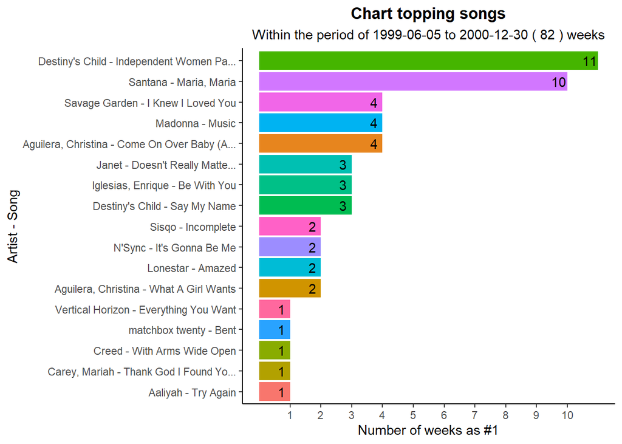

### Viz 4

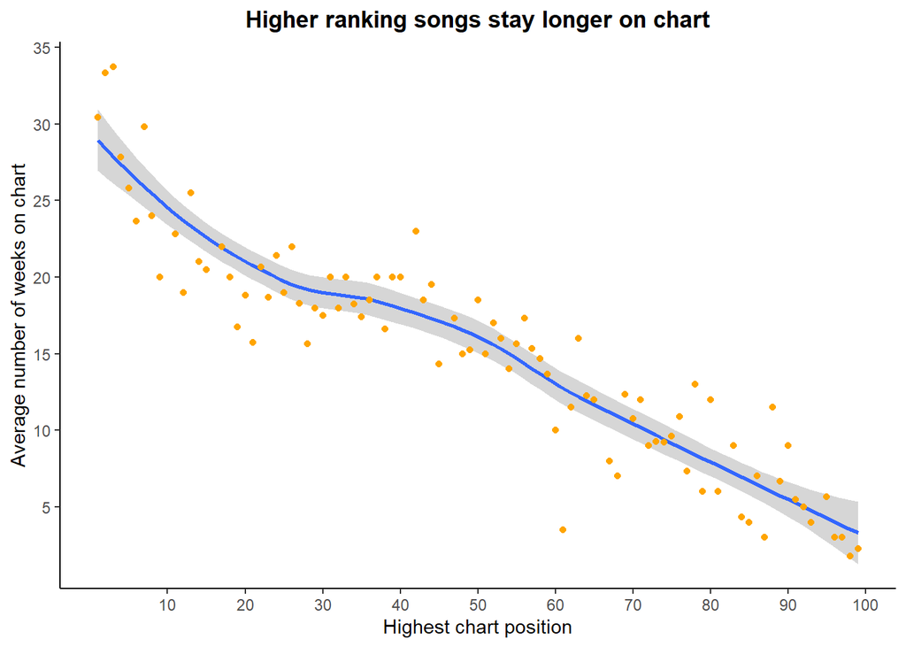

### Viz 5

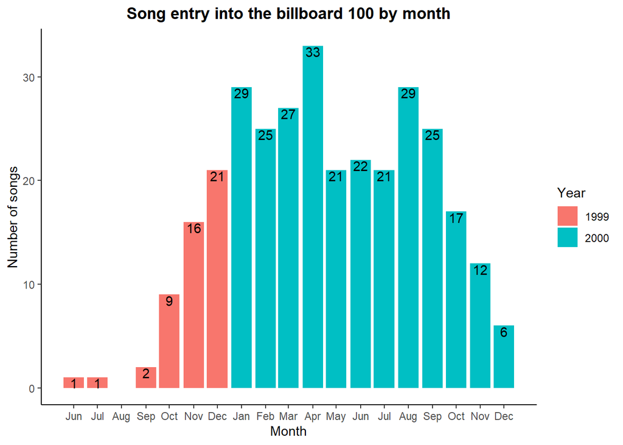

### Viz 6

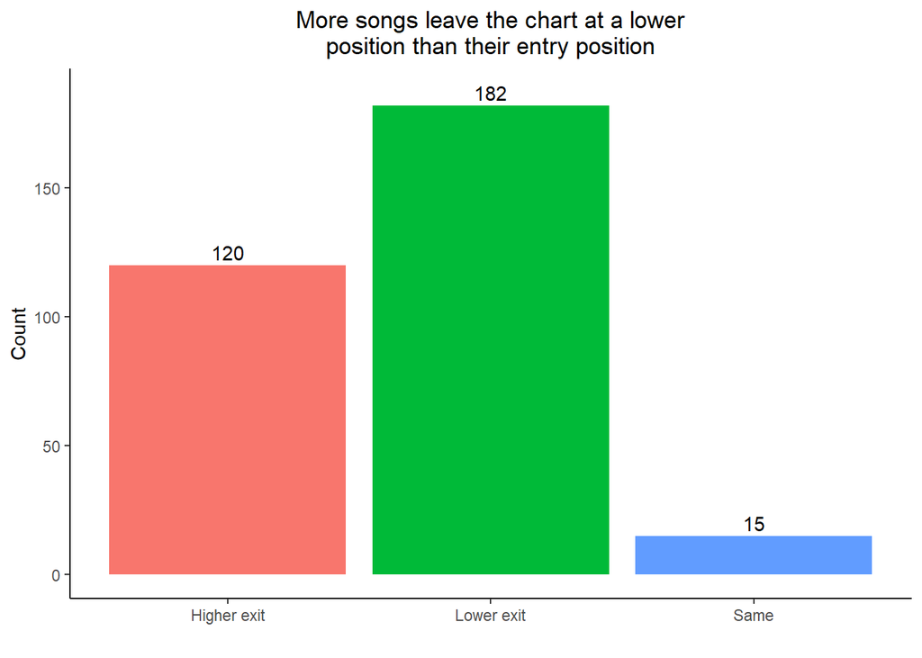

### Viz 7

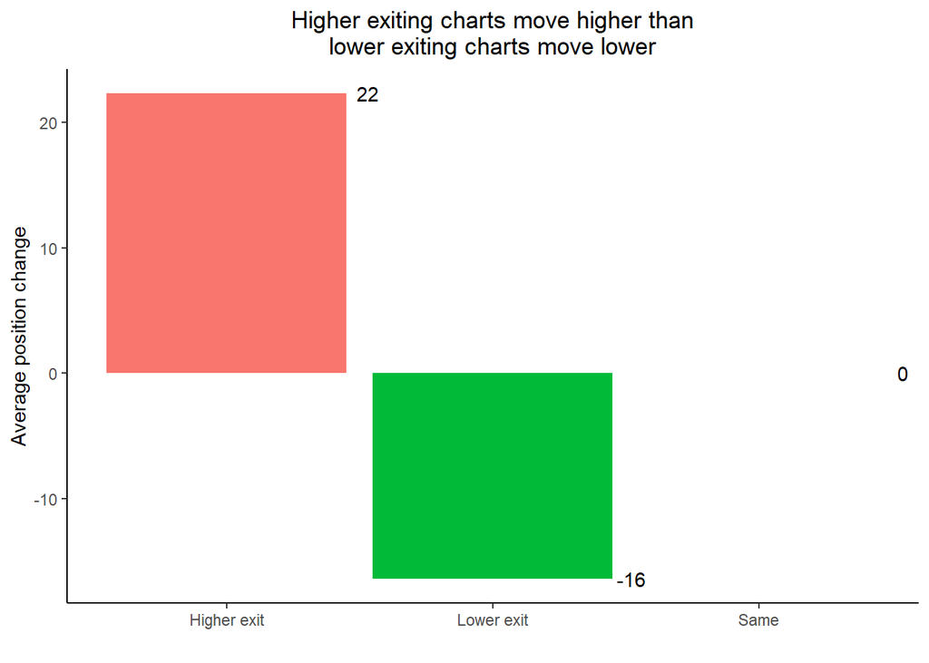

### Viz 8

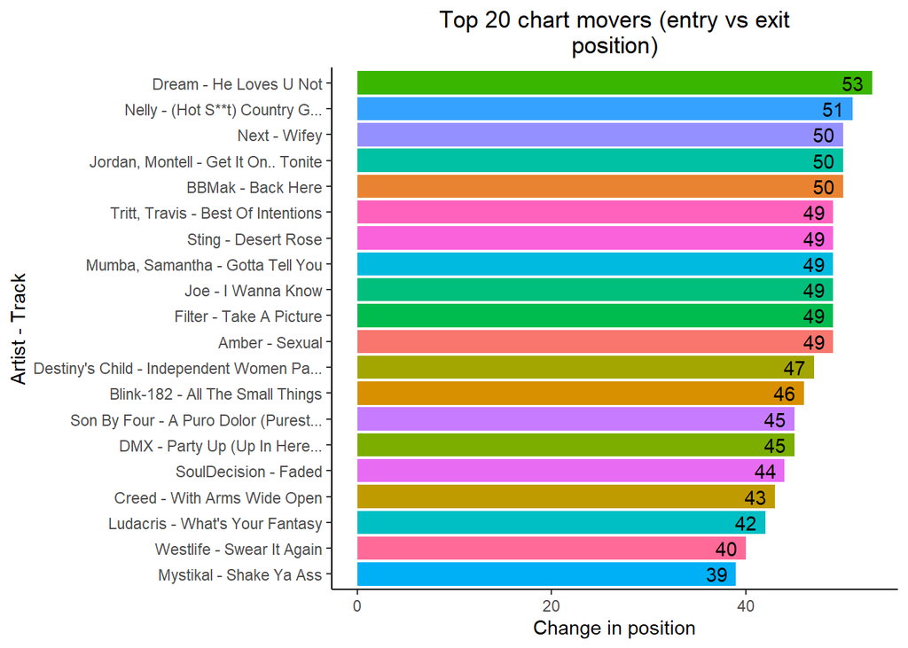

### Viz 9

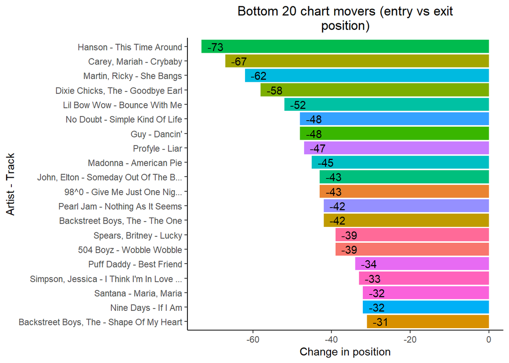

### Viz 10

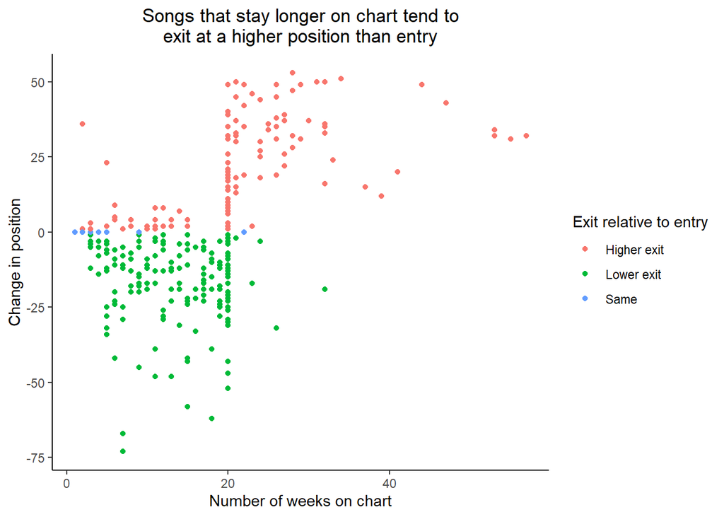

### Viz 11

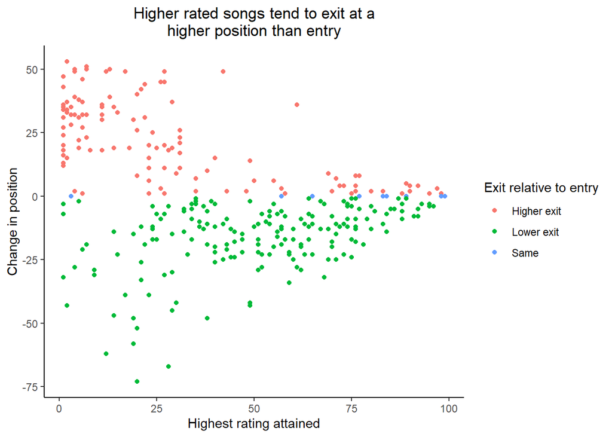

### Viz 12

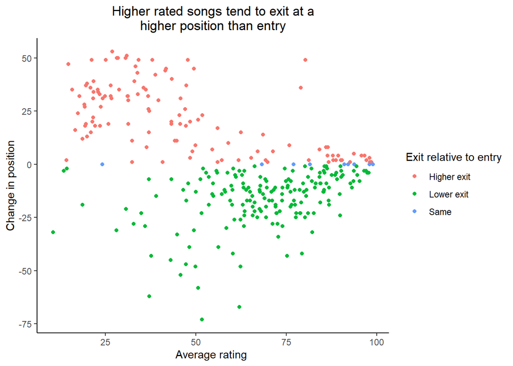

### Viz 13

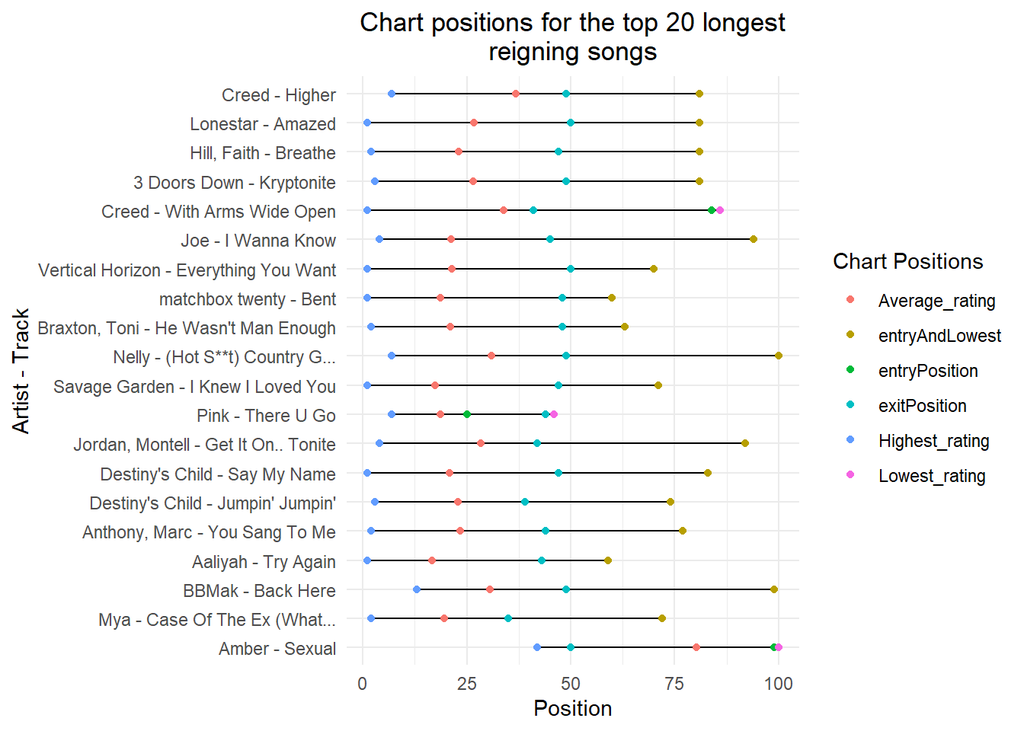

### Viz 14

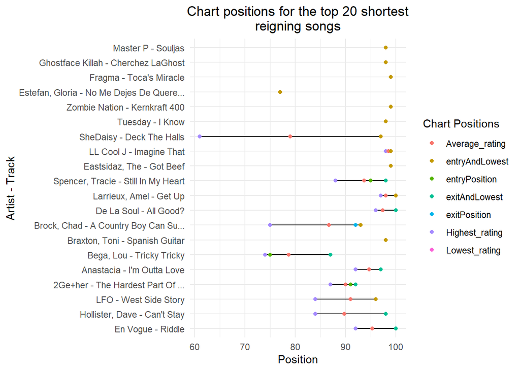

### Viz 15

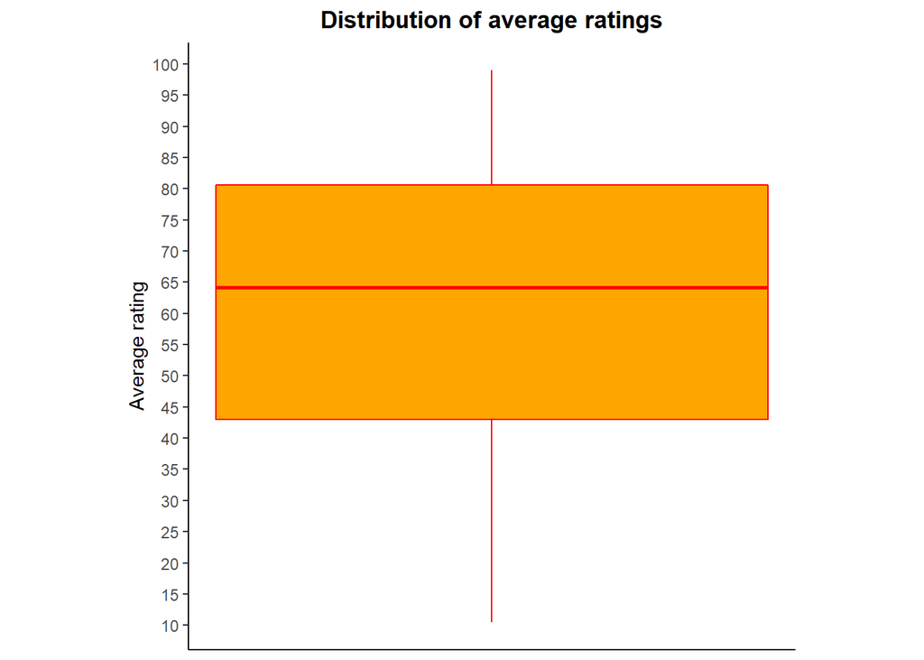